# Analysis of WNBA Salary and Performance Analysis (2024 Season)

Aastha Prakash

2024-10-09

# Introduction

This report analyzes the performance of WNBA players in the 2024 season based on their salaries, Points Per Possession (PPP), Player Efficiency Rating (PER), and Win Shares (WS). I limited my analysis to those who have played 1000 or more minutes, to ensure only those with statistically significant playing time would be included. By examining how these players perform with respect to their salaries, this project aims to provide visualizations and insight into team outcomes and player valuations. With the increasing visibility of women’s sports, I aim to offer a comprehensive review of player impact during the 2024 season.

# Loading Libraries and Data

```r
# Loading all necessary packages
library(dplyr) # for data manipulation
library(ggplot2) # for data visualization
library(stringr) # for string manipulation
library(scales) # for formatting labels
library(magick) # for high quality scatterplot images
```

```r
# Loading in CSV data files
salaries_df <- read.csv("/Users/aasthaprakash/Downloads/wnba_salaries.csv")
stats_df <- read.csv("/Users/aasthaprakash/Desktop/wnba_2024_stats.csv")
```

# Data Cleaning

```r
# Modify column names to be more readable
colnames(salaries_df)[colnames(salaries_df) == "Player..........................
                      ...................."] <- "Player"
colnames(salaries_df)[colnames(salaries_df) == "X2024.Salary"] <- "Salary"

salaries_df$Player <- trimws(salaries_df$Player)

# Function to format Player name into first initial and last name
format_player_name <- function(full_name) {
  name_parts <- unlist(strsplit(full_name, " "))
  if (length(name_parts) >= 2) {
    initial <- substr(name_parts[1], 1, 1)
    last_name <- name_parts[length(name_parts)]
    return(paste(initial, last_name, sep = ". "))
  } else {
    return(full_name)
  }
}

salaries_df$Player <- sapply(salaries_df$Player, format_player_name)
stats_df$Player <- sapply(stats_df$Player, format_player_name)

# Select relevant columns from each data frame
salaries_selected <- salaries_df[, c("Player", "Salary", "PPP")]
stats_selected <- stats_df[, c("Player", "PER", "WS", "MP")]

# Summarize salaries by player, including PPP
salaries_summary <- salaries_selected %>%
  group_by(Player) %>%
  summarise(
    Salary = max(Salary, na.rm = TRUE),  # Use max instead of sum
    PPP = max(PPP, na.rm = TRUE)  # Include max PPP
  )

# Merge salaries_summary with stats_selected dataframes
merged_df <- left_join(stats_selected, salaries_summary, by = "Player")

# Convert Salary to numeric (removing dollar signs and commas)
merged_df$Salary <- as.numeric(gsub("[$,]", "", merged_df$Salary))

# Setting a minutes cutoff to only display those who have played > 1000 minutes
minutes_cutoff <- 1000

# Filter players based on MP (Minutes Played)
filtered_merged_df <- merged_df %>% filter(MP > minutes_cutoff)

# Find mean of Salaries
mean(merged_df$Salary, na.rm = TRUE)
```

[output not shown]

The mean salary of WNBA players analyzed in the 2024 season is $100,710.50. This average provides a baseline for understanding player compensation across the league.

# Results

## Data Visualization

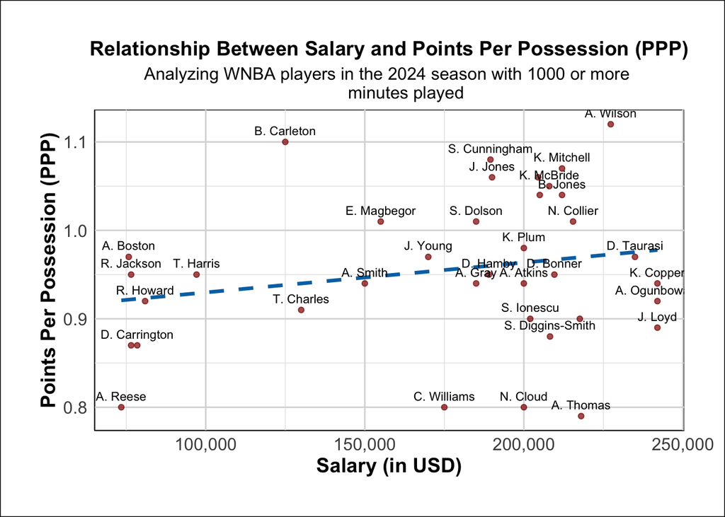

```r
# Create a custom theme!
custom_theme <- theme_minimal() +
  theme(
    text = element_text(size = 14),
    plot.title = element_text(face = "bold", hjust = 0.5, size = 14),
    plot.subtitle = element_text(size = 12, hjust = 0.5),
    axis.title = element_text(face = "bold"),
    axis.text = element_text(size = 12),
    panel.grid.major = element_line(color = "gray85", size = 0.5),
    panel.grid.minor = element_line(color = "gray90", size = 0.25),
    legend.position = "none",
    axis.line = element_line(size = 0.25, color = "black"),
    plot.margin = margin(1, 1, 1, 1, "cm"),
    panel.background = element_rect(fill = "white"),
    plot.background = element_rect(fill = "white"),
  )

# Scatter plot for Salary vs PPP
ggplot(filtered_merged_df, aes(x = Salary, y = PPP)) +
  geom_point(color = "#8B0000", size = 1.5, alpha = 0.7) +
  geom_smooth(method = "lm", se = FALSE, color = "#0072B2", linetype = "dashed",
              linewidth = 1.2) +
  labs(title = "Relationship Between Salary and Points Per Possession (PPP)",
       subtitle = "Analyzing WNBA players in the 2024 season with 1000 or more
       minutes played",
       x = "Salary (in USD)", y = "Points Per Possession (PPP)") +
  scale_x_continuous(labels = label_comma()) +  # Format x-axis labels
  geom_text(aes(label = Player), vjust = -0.8, size = 3, check_overlap = TRUE) +
  custom_theme
```

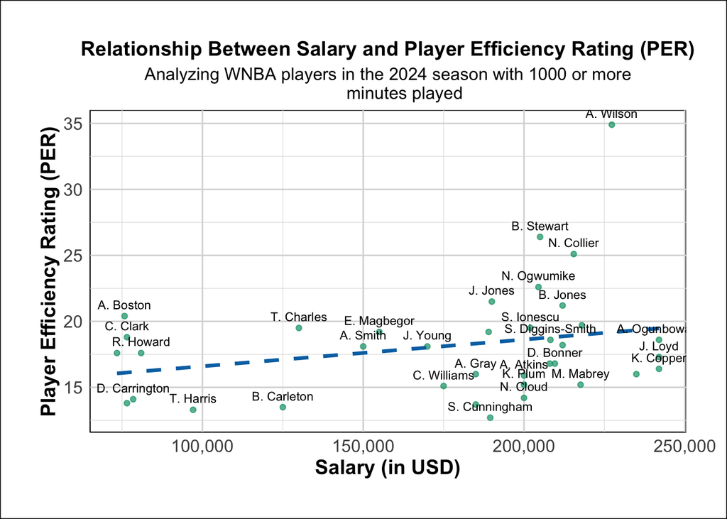

```r
#  Scatter plot for Salary vs PER
ggplot(filtered_merged_df, aes(x = Salary, y = PER)) +
  geom_point(color = "#009E73", size = 1.5, alpha = 0.7) +
  geom_smooth(method = "lm", se = FALSE, color = "#0072B2", linetype = "dashed",
              linewidth = 1.2) +
  labs(title = "Relationship Between Salary and Player Efficiency Rating (PER)",
       subtitle = "Analyzing WNBA players in the 2024 season with 1000 or more
       minutes played",
       x = "Salary (in USD)", y = "Player Efficiency Rating (PER)") +
  scale_x_continuous(labels = label_comma()) +  # Format x-axis labels
  geom_text(aes(label = Player), vjust = -0.8, size = 3, check_overlap = TRUE) +
  custom_theme
```

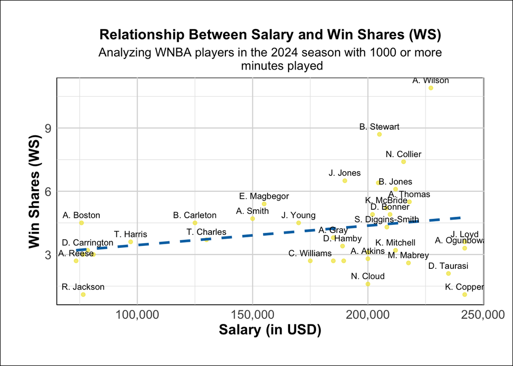

```r
#  Scatter plot for Salary vs WS
ggplot(filtered_merged_df, aes(x = Salary, y = WS)) +
  geom_point(color = "#F0E442", size = 1.5, alpha = 0.7) +
  geom_smooth(method = "lm", se = FALSE, color = "#0072B2", linetype = "dashed",
              linewidth = 1.2) +  # Add regression line
  labs(title = "Relationship Between Salary and Win Shares (WS)",
       subtitle = "Analyzing WNBA players in the 2024 season with 1000 or more
       minutes played",
       x = "Salary (in USD)", y = "Win Shares (WS)") +
  scale_x_continuous(labels = label_comma()) +
  geom_text(aes(label = Player), vjust = -0.8, size = 3, check_overlap = TRUE) +
  custom_theme
```

# Key Findings

# Conclusion

This analysis of WNBA players in the 2024 season, examining salary versus PER, PPP, and WS, visualizes how player performance aligns with compensation. Through the visualizations, it is apparent that there is a need for more equitable compensation in the league. Reassessment of how teams are allocating salaries could potentially lead to improved team performance.

Beyond individual performance analysis, the data also underscores that name recognition and legacy play a factor in player’s compensation, regardless of current performance. Diana Taurasi is a prime example of this – her legacy and marketability reflecting a broader influence on the league, fan engagement, and media attention.

To ensure fair compensation and the continued growth of the women’s sports, the WNBA must continue to showcase the talents of current stars while recognizing the lasting impact of legends like Taurasi. By analyzing key performance metrics and salaries, the WNBA can bridge the gap between performance and recognition, driving greater visibility and investment into women’s sports.